# Period-Doubling Bifurcation

Longxiao

2023-04-16

> This is a demonstration of **period-doubling bifurcations**. Here, I demonstrate how period-doubling bifurcations emerge in a logistic population growth model as the intrinsic growth rate varies, using R for simulation. For the formulation of the simplified logistic model and the emergence of period-doubling bifurcations in population growth, refer to May’s classic paper [*Biological Populations with Nonoverlapping Generations: Stable Points, Stable Cycles, and Chaos*](https://www.science.org/doi/10.1126/science.186.4164.645).

In a dynamical system, the emergence of *chaos* is closely related to **period-doubling bifurcations** that occur as system parameters change. Simply put, as the parameter varies, the stable state of the system bifurcates, eventually leading to chaos once a certain threshold is reached. We begin with the simplest system that exhibits period-doubling bifurcations, studying the dynamical characteristics of a difference equation with a quadratic term, and attempt to understand the nature of period-doubling bifurcations.

# 1 Logistic Growth of a Population

The story begins with a classic question in theoretical biology and ecology: How does a population change over time?

Consider a model where there is no generation overlap, and individuals are born and die at constant rates $g$ and $b$, respectively. The population grows at a constant rate $r = g - b$. A difference equation with only a linear term (which behaves simply) is used to describe the dynamics of such a model:

$$N_t = r N_{t-1} \tag{1}$$

We could simulate this system from $N_0 = 0.6$, with different intrinsic rate $r = 0.6,-0.6,2,-2$ (include values that are positive or negative, larger than $1$ or not, notice if $r = 1$ then $N_t = N_0$ for all $t$).

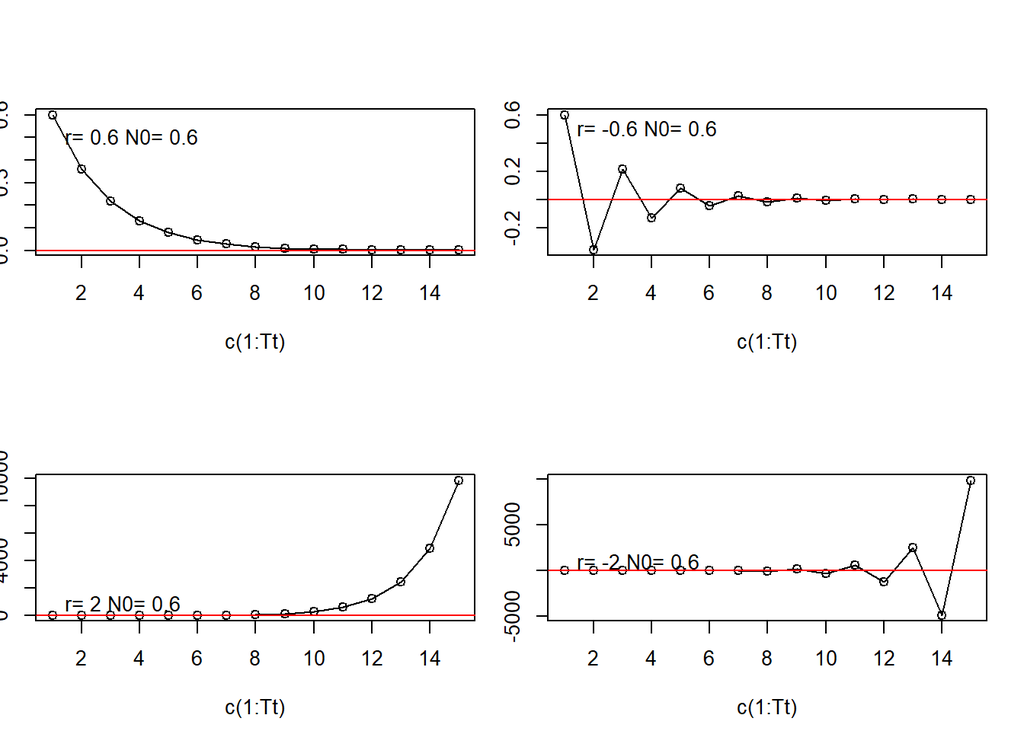

```r
Tt=15
r=c(0.6,-0.6,2,-2)
N0=0.6

SDF<-function(r,N0){
  N<-integer(Tt)
  N[1]=N0
  for(i in 2:Tt){
  N[i]=r*N[i-1]
  }
  return(N)
}

par(mfrow=c(2,2),pin=c(3,1))

for (j in r) {
  N<-SDF(j,N0)
  plot(c(1:Tt),N,type = "o")
  ptext<-paste("r=",j,"N0=",N0)
  abline(h=0,col="red")
  text(1,(600*abs(j)-359.5),pos= 4,ptext)
}
```

Or, we could simulate with different initial population size:

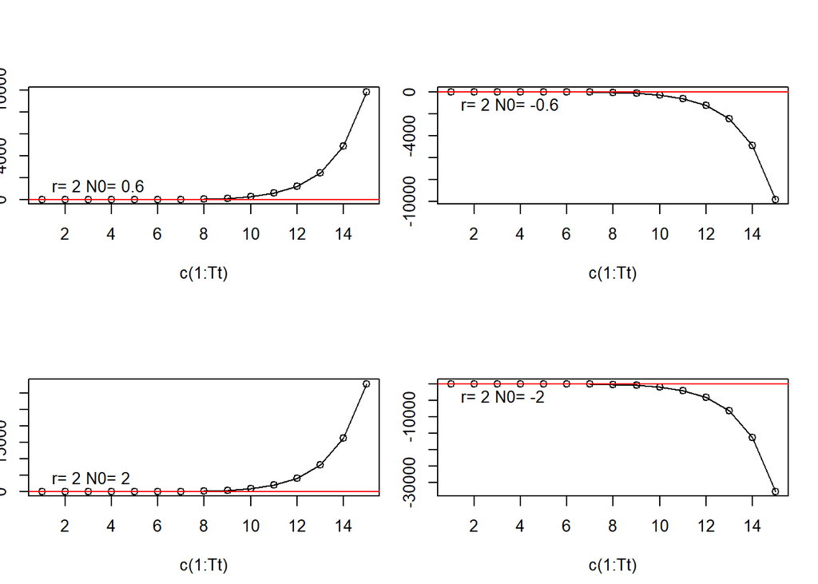

```r
Tt=15
r=2
N0=c(0.6,-0.6,2,-2)

par(mfrow=c(2,2),pin=c(3,1))

for (j in N0) {
  N<-SDF(r,j)
  plot(c(1:Tt),N,type = "o")
  ptext<-paste("r=",r,"N0=",j)
  abline(h=0,col="red")
  text(1,2000*j,pos= 4,ptext)
}
```

With a continuous time, the system could also be modeled by a difference equation:

$$\frac{dN}{dt} = rN$$

which has a solution $N_t = Ce^{rt}$. The differential equation looks like ($r=2$, $N_0 = 0.01$, $t \in (1,8)$):

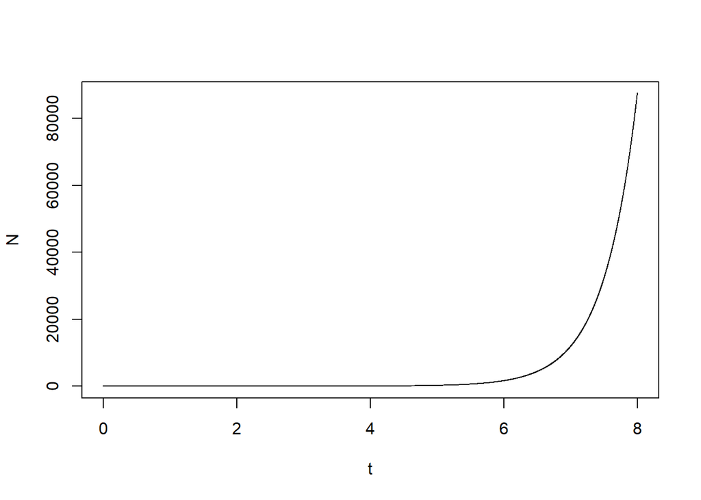

```r
r<-2
T1<-8
delta_t<-0.001
t<-seq(from = 0, to = T1, by = delta_t)
N0<-0.01

N<-integer(length(t)) #vector of population size
N[1]=N0       #initial population size N_0

for(i in 2:length(t)){
  N[i]=N[i-1]+delta_t*r*N[i-1]  #iterate function
}

logi_map<-cbind(t,N)
names(logi_map)<-c("t","N")
plot(logi_map, pch = ".")
```

However, a real population typically cannot grow at a constant rate, as there are various limitations such as nutrition, space, and other resources. As a result, we introduce an environmental capacity $K$ into the model, which represents the maximum population size that can be sustained by the environment:

$$N_t = rN_{t-1}\left(1 - \frac{N_{t-1}}{K}\right) \tag{2}$$

Here, $N_t$ represents the population size at time $t$, $r$ is the intrinsic growth rate of the population, and $K$ is the environmental capacity. With a simple transformation, the equation can be rewritten into a general form for this class of models:

$$N_t = rN_{t-1}(1 - N_{t-1}) \tag{3}$$

Note that the system’s dynamics are now governed by a single parameter $r$.

> The transformation from Equation (2) to Equation (3) removes the dimensional units, making the dynamical properties clearer and more concise. (The specific transformation can be skipped.)
> $$\text{Let: } a_t = \frac{N_t}{K} \\
> a_t = ra_{t-1}(1 - a_{t-1}')$$

> which is the same form as Equation (3).

It is easy to see that under the given constraints: $N_t$ lies within the interval [0, 1] (meaning the population size is positive and does not exceed the environmental carrying capacity), and $r$ is greater than zero (indicating population growth). Equation (3) has a fixed point:

$$N^* = rN^*(1 - N^*)$$

Solving for $a$ gives:

$$N^* = 1 - \frac{1}{r} \tag{4}$$

When the value of $r$ is relatively small, the system will converge to the fixed point regardless of the initial value.

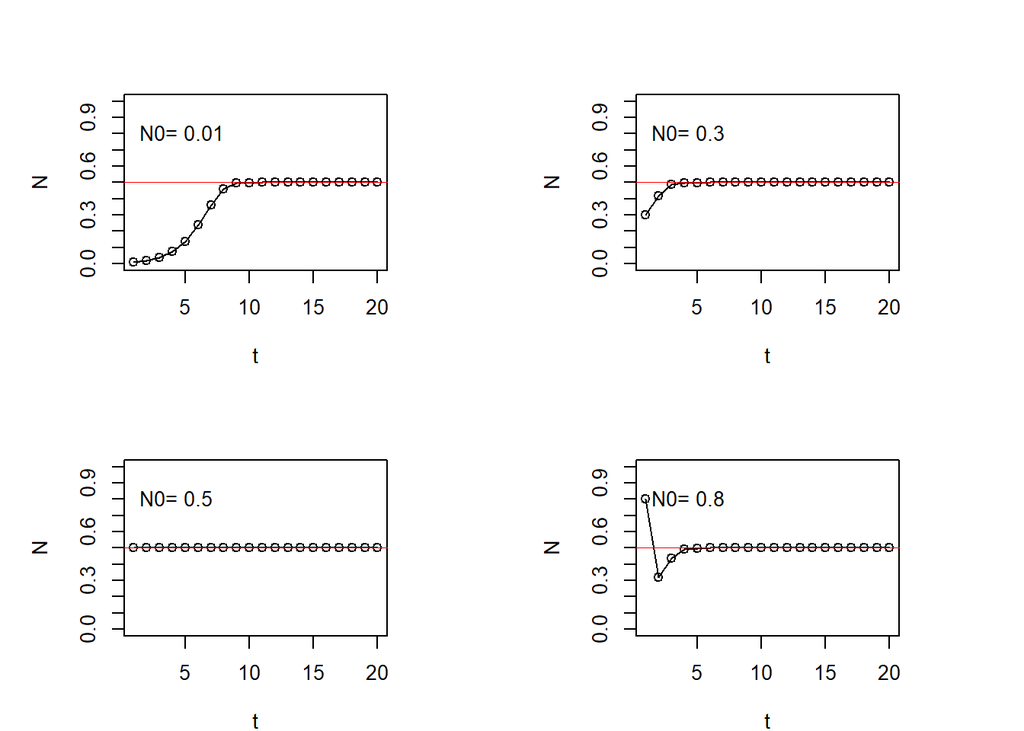

```r
Tt<-20
r<-2
N0<-c(0.01,0.3,0.5,0.8)
Nt<-length(N0)
N<-integer(Tt)

par(mfrow=c(2,2),pin=c(8,6))

for (j in N0) {
  N[1]=j
for(i in 2:Tt){
  N[i]=r*N[i-1]*(1-N[i-1])
}
t<-c(1:Tt)
par(pin=c(1.8,1.2))
plot(t,N,type = "o",ylim = c(0,1),yaxp = c(0,1,10))
abline(h=0.5,lwd=0.5,col="red")
ptext<-paste("N0=",j)
  text(0.5,0.8,pos= 4,ptext)
}
```

With smaller initial values $N_0$, the system exhibits behavior characteristic of nonlinearity. Followed equation(4), the fixed point should exist with all $r > 1$. But the system will not always converge when the $r$ is getting large. We will discuss it later.

Under continuous-time conditions, this model is known as **logistic growth**, described by the following equation:

$$\frac{dN}{dt} = rN(1 - N)$$

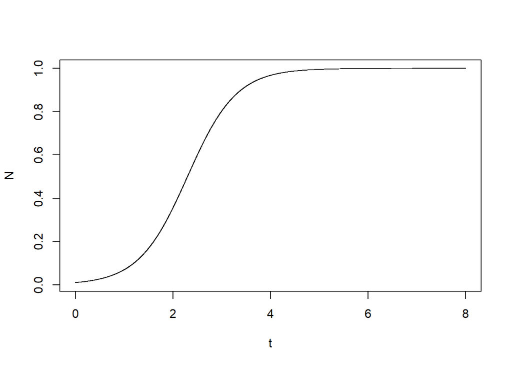

```r
r<-2
T1<-8
delta_t<-0.001
t<-seq(from = 0, to = T1, by = delta_t)
N0<-0.01

N<-integer(length(t)) #vector of population size
N[1]=N0       #initial population size N_0

for(i in 2:length(t)){
  N[i]=N[i-1]+delta_t*r*N[i-1]*(1-N[i-1])  #iterate function
}

logi_map<-cbind(t,N)
names(logi_map)<-c("t","N")
plot(logi_map, pch = ".")
```

# 2 Period-Doubling Bifurcations

Now it is time to discuss the complex dynamics of the logistic model with larger $r$. The exponential growth model has very simple behavior. When we introduce a quadratic term into the system (as logistic model), the situation seems not change significantly. However, as we gradually increase the value of the growth parameter $r$, the state of the system also changes accordingly:

We simulate the discrete-time logistic model with $r = 0.8,2.5,3.2,3.5,3.55,3.6,3.99,4.1$

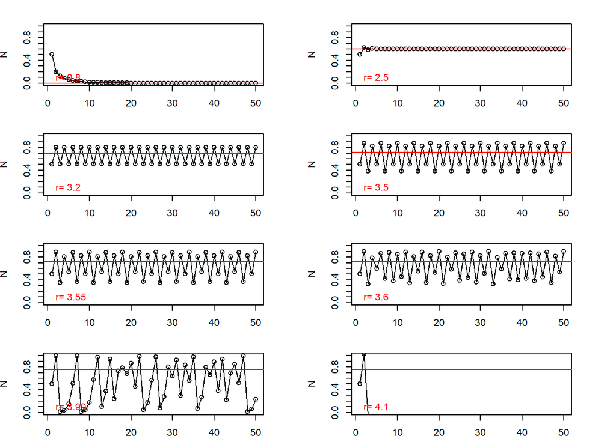

```r
Tt=50 #迭代次数
r=c(0.8,2.5,3.2,3.5,3.55,3.6,3.99,4.1) #增长率参数
N0=0.5 #初始值

N<-integer(Tt) #种群数量

par(mfrow=c(4,2))

for (j in r) {
  for(i in 2:Tt){
    N[1]=N0
    N[i]=j*N[i-1]*(1-N[i-1])
  }
  t<-c(1:Tt)
  par(pin=c(2.5,0.7))
  plot(t,N,type = "o",ylim = c(0,1),yaxp = c(0,1,10))
  abline(h=max((1-1/j),0),col="red")
  ptext<-paste("r=",j)
  text(0.5,0.1,pos= 4,ptext,col="red")
}
```

Although the system still tends to approach the fixed point in the long run, it sometimes fails to reach it precisely and instead begins to oscillate. And once the $r$ is getting much larger, it is even hard to notice the oscillation. As the value of $r$ continues to increase, the nature of the system’s long-term fluctuations also changes.

It becomes evident that the period of these fluctuations varies with $r$. In other words, the final state of the system—and how many such states exist—depends on the value of $r$ (for example, $2$ when $r = 3.2$, $4$ when $r = 3.5$). Also, we can notice that the number of different state seems follows the series $n = 2^k$.

We can visualize the positions of the system’s final states for different values of $r$ in a diagram:

```r
logistic_ref<-function(r,N){
  return(r*N*(1-N))
} #logistic map

par_map<-function(r,N0,t,k,func){
  N<-integer(t) #population size
  N[1]=N0       #initial population

  a0<-as.data.frame(matrix(nrow = 0, ncol = 2))
  #dataframe of r-N*

  for (j in r) {
    for(i in 2:t){
      N[i]=func(j,N[i-1])
    }
    a<-cbind(rep(j,k),N[(t-k+1):t])
    a0<-rbind(a0,a)
  }
  names(a0)<-c("r","N")
  return(a0)
}
```

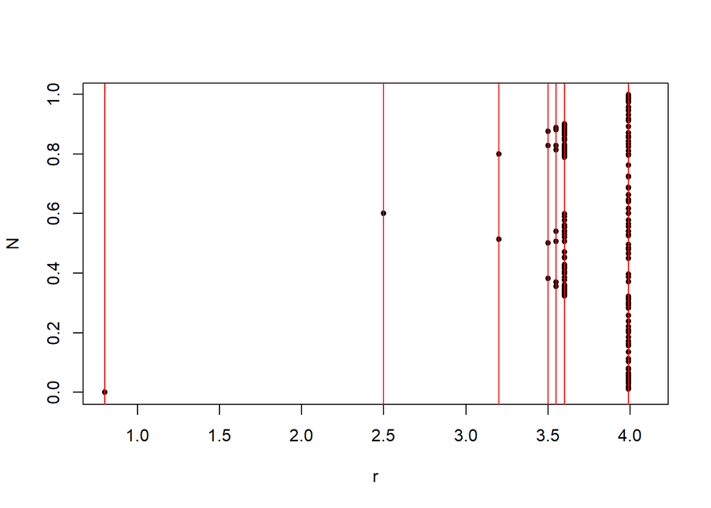

```r
r=c(0.8,2.5,3.2,3.5,3.55,3.6,3.99,4.1) #r, intrinsic rate
N0=0.6 #initial population size
t=1000 #iterate times
k=100 #number of kept final state

ap1<-par_map(r,N0,t,k,logistic_ref)
plot(ap1,pch=20,cex = 1)

abline(v=r[1:7],col="red")
```

Next, we sample the parameter $r$ more densely and again plot the system states. We can clearly observe the bifurcation of system states. The system transitions from a single stable point, to oscillations between two states, then four states, with increasingly longer periods, and eventually enters an aperiodic chaotic regime.

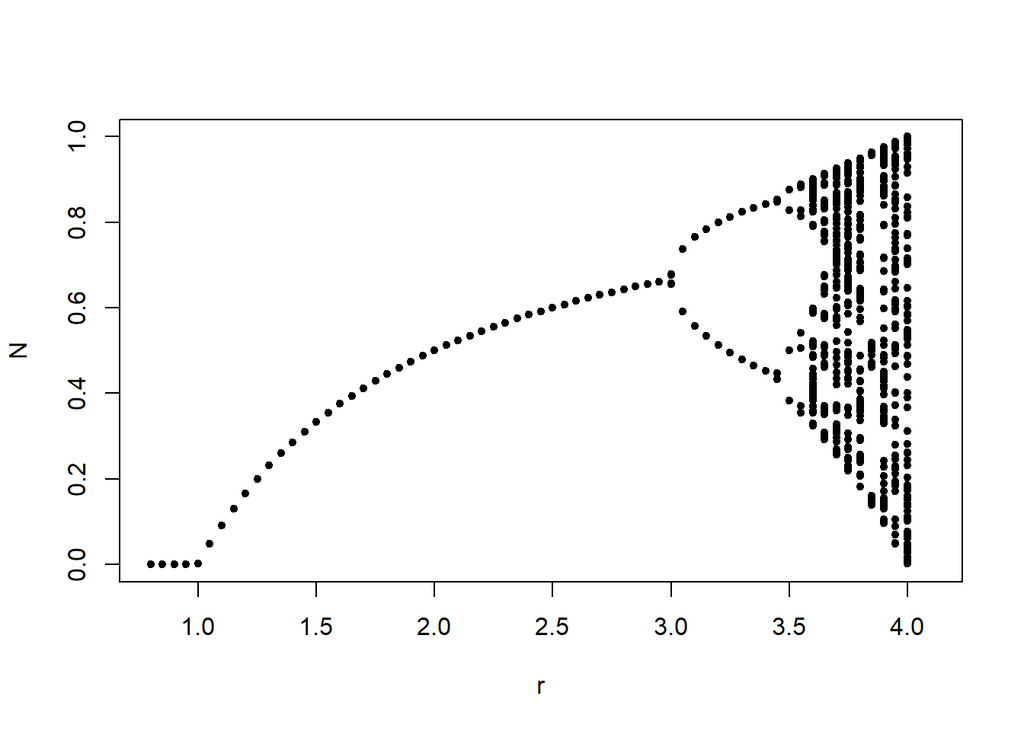

```r
r=seq(from = 0.8, to = 4.1, by = 0.05)
N0=0.6
t=500
k=100

ap2<-par_map(r,N0,t,k,logistic_ref)
plot(ap2,pch=20,cex = 1)
```

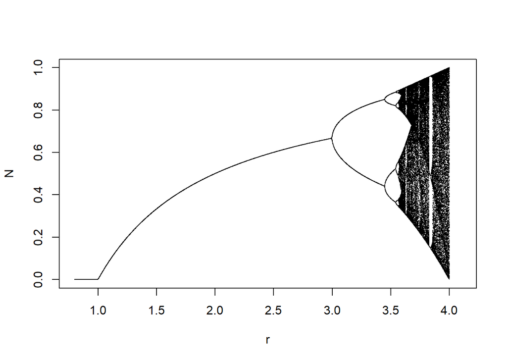

```r
r=seq(from = 0.8, to = 4.1, by = 0.001)
N0=0.6
t=500
k=100

a0<-par_map(r,N0,t,k,logistic_ref)
plot(a0,pch = ".")
```

> Another way to generate a bifurcation diagram is by iterating from a single initial state. The transitions between different periodic behaviors appear rougher compared to the diagram above, which also depends on the resolution of the simulation.

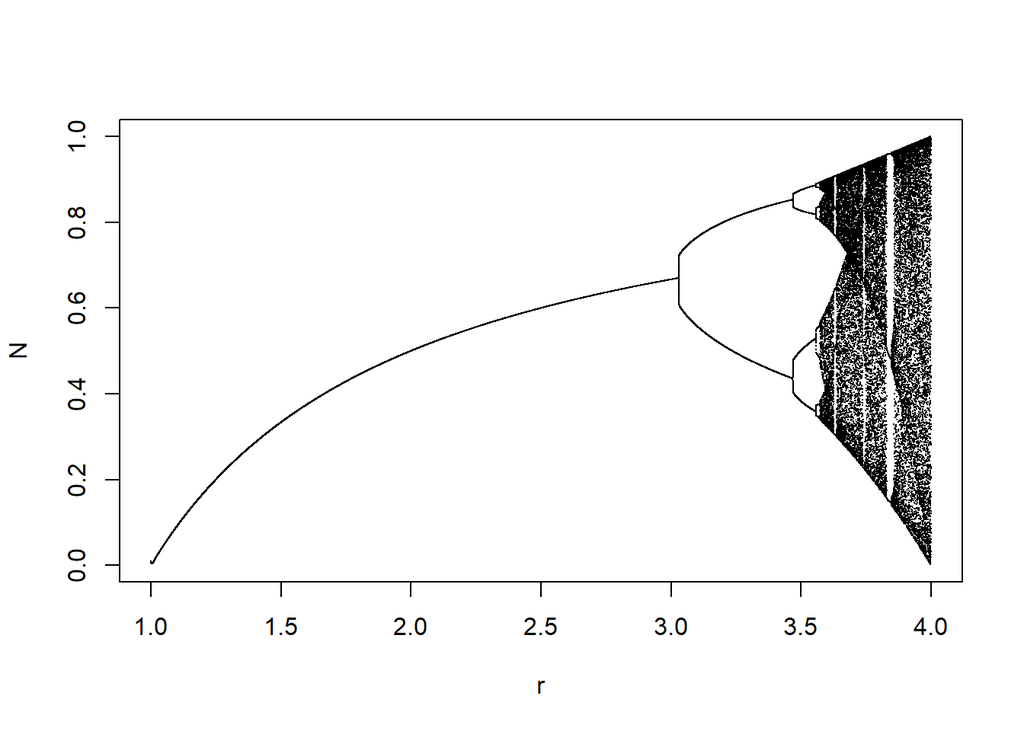

```r
t<-200000
r<-seq(from=1.0, to=4.0, length.out=t)
N0<-0.01

N<-integer(t)
N[1]=N0

for (i in 2:t) {
    N[i]=r[i]*N[i-1]*(1-N[i-1])
  }
b<-cbind(r,N)
plot(b,pch = ".")
```

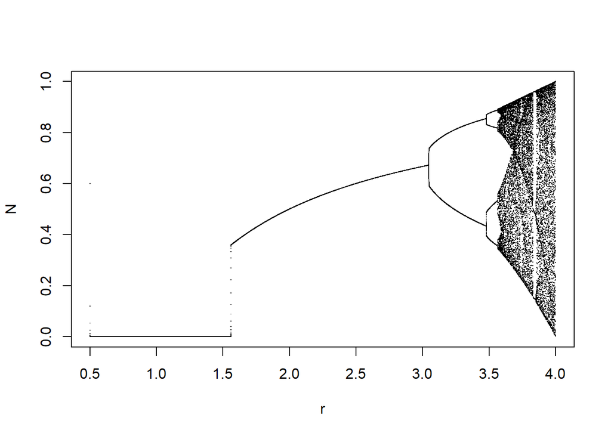

```r
t<-100000
r<-seq(from=0.5, to=4.0, length.out=t)
N0<-0.6

N<-integer(t)
N[1]=N0

for (i in 2:t) {
    N[i]=r[i]*N[i-1]*(1-N[i-1])
  }
b<-cbind(r,N)
plot(b,pch = ".")
```

# 3 Basic Analysis

## 3.1 Feigenbaum Constants: pattern of bifurcations

In period-doubling bifurcations, the period of oscillations doubles as the parameter increases. We then search for the parameter values at which state transitions occur, and investigate their underlying pattern.

```r
f <- 6 # Number of bifurcations to find
period <- 2 # Minimum period
cycle2 <- integer(f + 1)
t = 2000 # Number of iterations
N0 = 0.6 # Initial value

pointfind <- function(r, num_point) {
  # r is the logistic map parameter, num_point is the period size to search for

  N <- integer(t) # Population size
  N[1] = N0       # Initial population size

  for (i in 2:t) {
    N[i] = logistic_ref(r, N[i-1]) # Logistic mapping, iterating to get population size changes
  }

  if (abs(N[t] - N[t - num_point]) > 0.000001) return(1)
  # Check if it has a cycle, i.e., whether the population size is equal for the specified period
  # Since it is only approaching the limit cycle, the values do not need to be exactly equal, they just need to be very close
  # Return 1 if no cycle is found
  else return(0)
}

lr <- 0 # Left boundary
rr <- 4 # Right boundary

for (m in 0:f) {
  # m is the number of bifurcations on the left side, 2^m is the number of bifurcations on the left
  while ((rr - lr) > 0.0000001) {
    midr <- ((rr + lr) / 2) # Middle value of the current interval
    if (pointfind(midr, (period^m)) == 1) rr <- midr
    # If the cycle at the middle value is not the bifurcation left cycle, the middle value is in the bifurcation right side
    else lr <- midr
    # Otherwise, the middle value is on the bifurcation left side
  }
  cycle2[m + 1] <- midr # Found the bifurcation point
  rr <- 4 # Reset the right boundary to 4, left boundary remains the same
}
# Use binary search to find the bifurcation points

print(cycle2)
```

```
## [1] 2.994658 3.447641 3.543449 3.564222 3.568694 3.569679 3.569885
```

It seems that these values are converge to a value close to $3.57$, which suggest that there is a limitation for period-doubling bifurcations. Just like in the diagram, the red lines for period doubling getting dense.

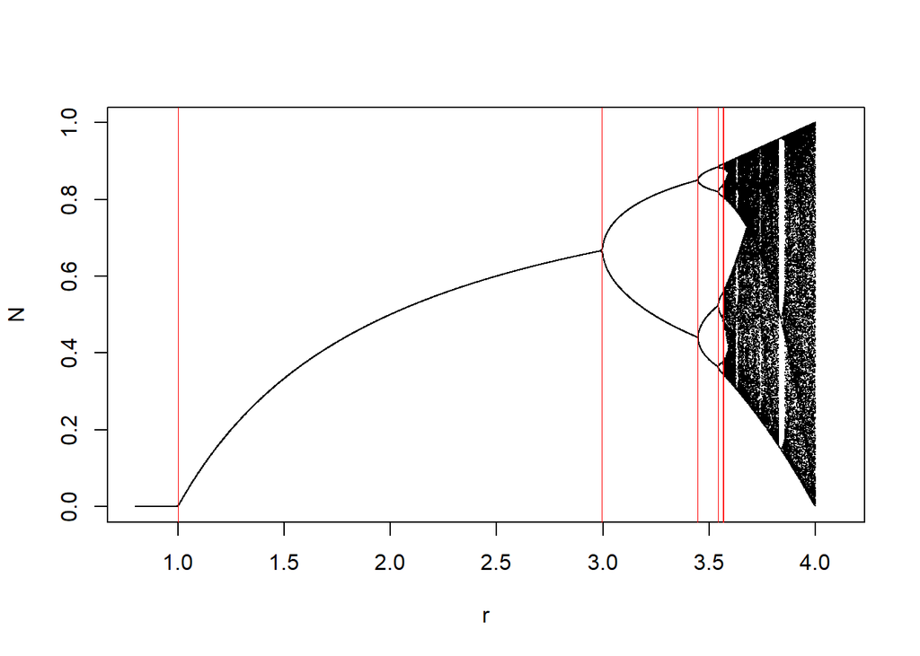

```r
plot(a0,pch = ".")
abline(v=1,lwd=0.5,col="red")
for (i in cycle2) {
  abline(v=i,lwd=0.5,col="red")
}
```

To find more patterns, we calculate the interval of period doubling:

```r
c2_gap<-integer(f+1)
c2_gap[1]<-cycle2[1]-1
for (i in 2:(f+1)) {
    c2_gap[i]<-cycle2[i]-cycle2[i-1]
}
print(c2_gap)
```

```
## [1] 1.9946580529 0.4529824484 0.0958083479 0.0207735855 0.0044712256
## [6] 0.0009850738 0.0002066808
```

```r
c2_gaprate<-integer(f)
for (i in 1:f) {
    c2_gaprate[i]<-c2_gap[i]/c2_gap[i+1]
}
print(c2_gaprate)
```

```
## [1] 4.403389 4.728006 4.612028 4.646061 4.538975 4.766160
```

By roughly simulation and calculation, the value of parameter $r$ for period doubling seems a geometric sequence, with common ratio around $4.6$.

```r
fit<-lm(c2_gaprate ~ 1)
summary(fit)
```

```
##
## Call:
## lm(formula = c2_gaprate ~ 1)
##
## Residuals:
##         1         2         3         4         5         6
## -0.212380  0.112236 -0.003742  0.030291 -0.076795  0.150390
##
## Coefficients:
##             Estimate Std. Error t value Pr(>|t|)
## (Intercept)   4.6158     0.0539   85.64 4.11e-09 ***
## ---
## Signif. codes:  0 '***' 0.001 '**' 0.01 '*' 0.05 '.' 0.1 ' ' 1
##
## Residual standard error: 0.132 on 5 degrees of freedom
```

We then fit the sequence to a linear model. The estimation of common ratio is $4.6158\pm0.0539$. Actually, This value is called *Feigenbaum Constants*, $\delta$, which is a general constant in the world of chaos, refers to [Quantitative universality for a class of nonlinear transformations](https://doi.org/10.1007/BF01020332).

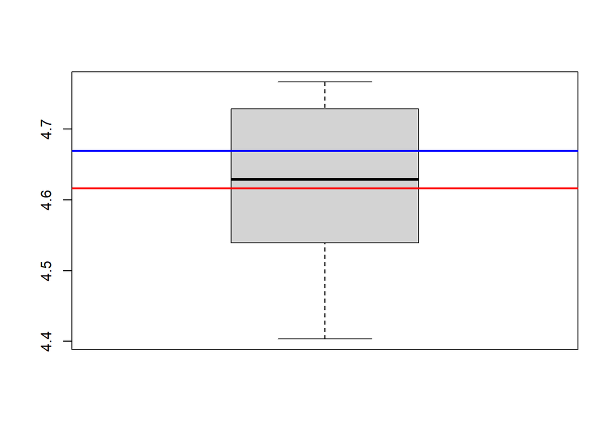

```r
boxplot(c2_gaprate)
F_cons<-4.669201609  #Feigenbaum Constants
abline(h = fit$coefficients,lwd=2, col="red")
abline(h = F_cons,lwd=2, col="blue")
```

```r
c2_gap0<-2
c2_total0<-1+c2_gap0*(F_cons/(F_cons-1))
print(c2_total0)
```

```
## [1] 3.545078
```

```r
c2_total1<-1+c2_gap[1]*(fit$coefficients/(fit$coefficients-1))
print(c2_total1)
```

```
## (Intercept)
##    3.546313
```

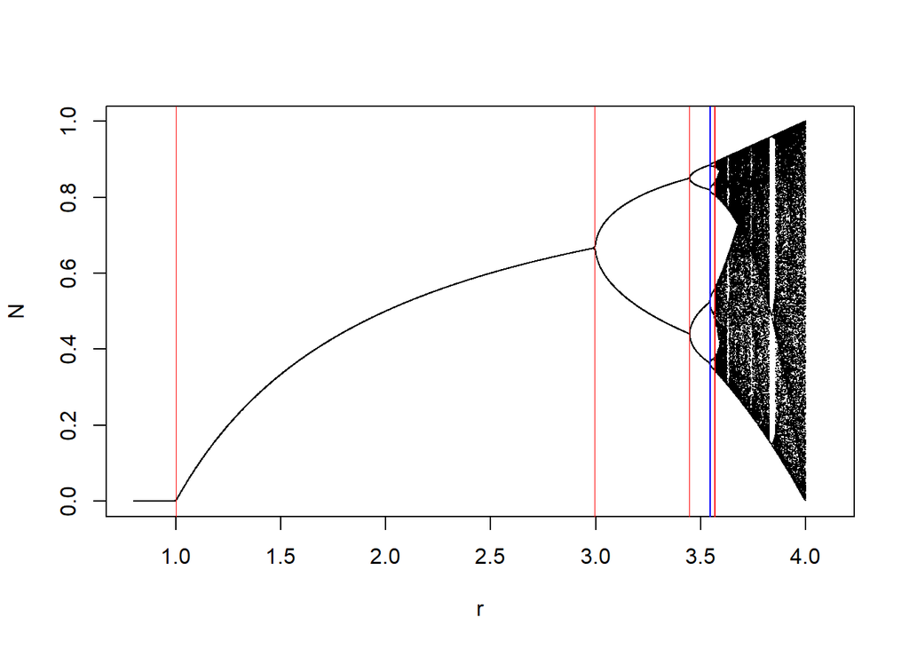

```r
plot(a0,pch = ".")
abline(v=1,lwd=0.5,col="red")
for (i in cycle2) {
  abline(v=i,lwd=0.5,col="red")
}
abline(v=c2_total1,col="blue")
```

## 3.2 Fractal Features

Each branch of the bifurcation shows a similar pattern, which is closely related to fractal feature. Here we showed some parts of the above period-doubling bifurcation.

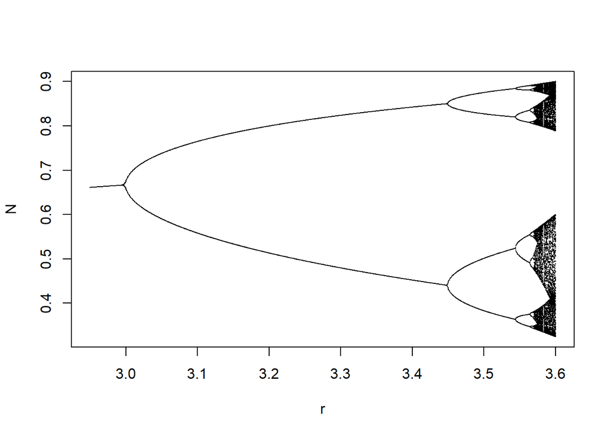

```r
t=1000
N0=0.6
k=200
r_b1=seq(from = 2.95, to = 3.6, by = 0.0005)
map_b1<-par_map(r_b1,N0,t,k,logistic_ref)
plot(map_b1,pch = ".")
```

```r
t=1000 #迭代次数
N0=0.6 #初始值
k=200 #绘图保留次数
r1=seq(from = 3.62, to = 3.64, by = 0.00004)
r2=seq(from = 3.73, to = 3.75, by = 0.00004)
r3=seq(from = 3.82, to = 3.88, by = 0.00004)

map1<-par_map(r1,N0,t,k,logistic_ref)
map2<-par_map(r2,N0,t,k,logistic_ref)
map3<-par_map(r3,N0,t,k,logistic_ref)
```

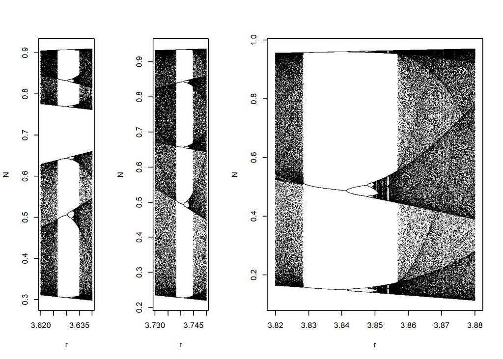

```r
layout(matrix(c(1,2,3),1,3,byrow = T),widths = c(1,1,2.4))
plot(map1,pch = ".")
plot(map2,pch = ".")
plot(map3,pch = ".")
```

## 3.3 Chaos and Initial Condition Sensitivity

The upper bound of period bifurcation suggest chaos with larger $r$. Again, we simulated the system with different $r$, but also with two close initial state.

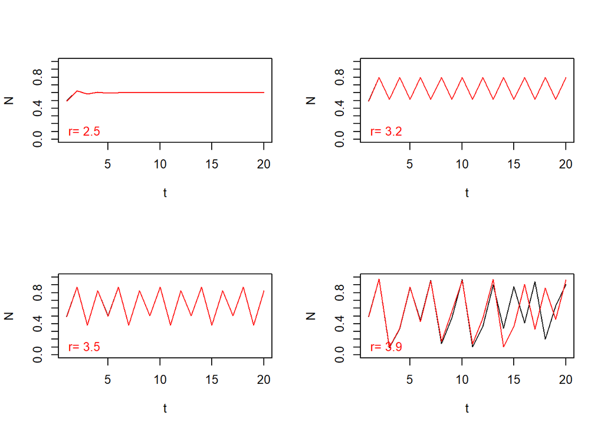

```r
Tt=20 #迭代次数
r=c(2.5,3.2,3.5,3.9) #增长率参数
N0=0.5 #初始值
l=0.01

N<-integer(Tt) #种群数量
N1<-integer(Tt)

par(mfrow=c(2,2))

for (j in r) {
  for(i in 2:Tt){
    N[1]=N0
    N1[1]<-N[1]-l
    N[i]=j*N[i-1]*(1-N[i-1])
    N1[i]=j*N1[i-1]*(1-N1[i-1])
  }
  t<-c(1:Tt)
  plot(t,N,type = "l",ylim = c(0,1),yaxp = c(0,1,10))
  lines(t,N1,col="red")
  ptext<-paste("r=",j)
  text(0.5,0.1,pos= 4,ptext,col="red")
}
```

As we can see here, when the $r$ is larger, the system dynamics is sensitive with initial state, and the error becomes unpredictable. We call this kind of phenomena *chaos*.

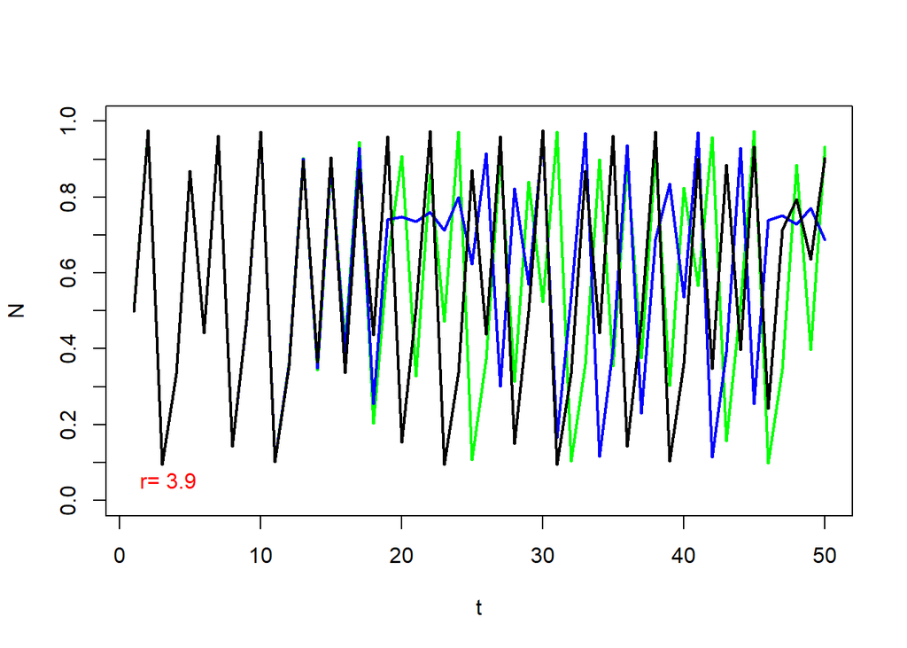

```r
Tt=50
r=3.9
N0=0.5
l=0.001

N<-integer(Tt)
N1<-integer(Tt)
N2<-integer(Tt)

N[1]=N0
N1[1]<-N[1]-l
N2[1]<-N[1]-2*l
for(i in 2:Tt){
  N[i]=r*N[i-1]*(1-N[i-1])
  N1[i]=r*N1[i-1]*(1-N1[i-1])
  N2[i]=r*N2[i-1]*(1-N2[i-1])
}
t<-c(1:Tt)

plot(t,N,type = "l",col="green",lwd = 2,ylim = c(0,1),yaxp = c(0,1,10),)
lines(t,N1,col="blue",lwd = 2)
lines(t,N2,lwd = 2)

ptext<-paste("r=",j)
text(0.5,0.05,pos= 4,ptext,col="red")
```

# 4 Another example

Not only the logistic map have such an amazing property. Actually, other nonlinear functions could also work. For example, the sine function mapping:

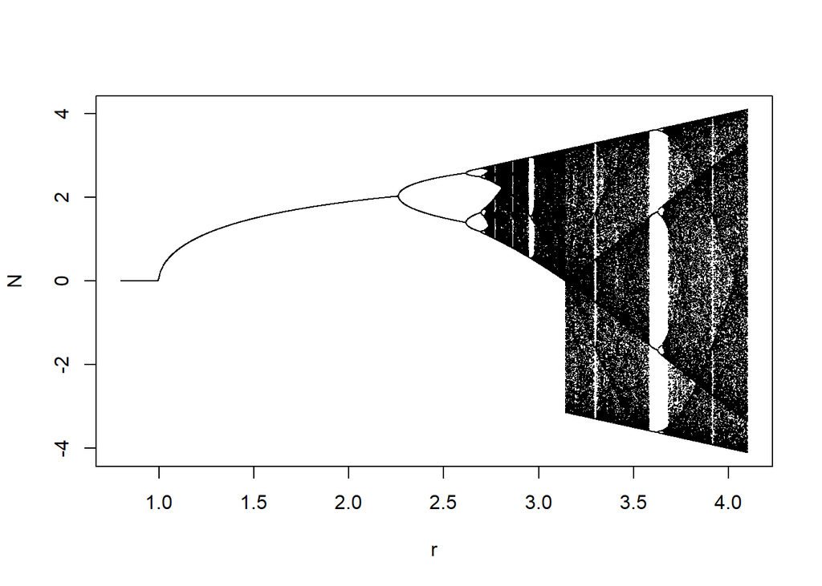

```r
sin_map<-function(r,N){
  return(r*sin(N))
} #logistic map

r=seq(from = 0.8, to = 4.1, by = 0.001)
N0=0.6
t=500
k=100

b0<-par_map(r,N0,t,k,sin_map)
plot(b0,pch = ".")
```

```r
f <- 6 # Number of bifurcations to find
period <- 2 # Minimum period
cycle3 <- integer(f + 1)
t = 2000 # Number of iterations
N0 = 0.6 # Initial value

pointfind <- function(r, num_point) {
  # r is the logistic map parameter, num_point is the period size to search for

  N <- integer(t) # Population size
  N[1] = N0       # Initial population size

  for (i in 2:t) {
    N[i] = sin_map(r, N[i-1]) # Logistic mapping, iterating to get population size changes
  }

  if (abs(N[t] - N[t - num_point]) > 0.000001) return(1)
  # Check if it has a cycle, i.e., whether the population size is equal for the specified period
  # Since it is only approaching the limit cycle, the values do not need to be exactly equal, they just need to be very close
  # Return 1 if no cycle is found
  else return(0)
}

lr <- 0 # Left boundary
rr <- 4 # Right boundary

for (m in 0:f) {
  # m is the number of bifurcations on the left side, 2^m is the number of bifurcations on the left
  while ((rr - lr) > 0.0000001) {
    midr <- ((rr + lr) / 2) # Middle value of the current interval
    if (pointfind(midr, (period^m)) == 1) rr <- midr
    # If the cycle at the middle value is not the bifurcation left cycle, the middle value is in the bifurcation right side
    else lr <- midr
    # Otherwise, the middle value is on the bifurcation left side
  }
  cycle3[m + 1] <- midr # Found the bifurcation point
  rr <- 4 # Reset the right boundary to 4, left boundary remains the same
}
# Use binary search to find the bifurcation points

print(cycle3)
```

```
## [1] 2.257495 2.615902 2.696711 2.714321 2.718180 2.719038 2.719240
```

```r
c3_gap<-integer(f+1)
c3_gap[1]<-cycle3[1]-1
for (i in 2:(f+1)) {
    c3_gap[i]<-cycle3[i]-cycle3[i-1]
}

c3_gaprate<-integer(f)
for (i in 1:f) {
    c3_gaprate[i]<-c3_gap[i]/c3_gap[i+1]
}
print(c3_gaprate)
```

```
## [1] 3.508570 4.435215 4.588714 4.563500 4.500455 4.247547
```

```r
fit<-lm(c3_gaprate ~ 1)
summary(fit)
```

```
##
## Call:
## lm(formula = c3_gaprate ~ 1)
##
## Residuals:
##        1        2        3        4        5        6
## -0.79876  0.12788  0.28138  0.25617  0.19312 -0.05979
##
## Coefficients:
##             Estimate Std. Error t value Pr(>|t|)
## (Intercept)   4.3073     0.1673   25.74 1.65e-06 ***
## ---
## Signif. codes:  0 '***' 0.001 '**' 0.01 '*' 0.05 '.' 0.1 ' ' 1
##
## Residual standard error: 0.4099 on 5 degrees of freedom
```